# Prediction of Parkinson's disease Using Machine Learning Classifiers

### Step 1 : Data Uploading and cleaning

```python
import numpy as np  # For Multi-dimensional array Calculation
import pandas as pd # For Data analysis and cleaning

# For ploting and visualization
import matplotlib.pyplot as plt
import seaborn as sns

from sklearn.preprocessing import StandardScaler
from sklearn.model_selection import train_test_split
from sklearn.metrics import accuracy_score
```

###### Uploading Dataset

```python
data =pd.read_csv('ReplicatedAcousticFeatures-ParkinsonDatabase.csv')
```

###### Printing Dataset and Dimensions

```python
print("The shape of the dataset is:{}".format(data.shape))
data.head()
```

```
The shape of the dataset is:(240, 48)
```

|  | ID | Recording | Status | Gender | Jitter_rel | Jitter_abs | Jitter_RAP | Jitter_PPQ | Shim_loc | Shim_dB | ... | Delta3 | Delta4 | Delta5 | Delta6 | Delta7 | Delta8 | Delta9 | Delta10 | Delta11 | Delta12 |
| --- | --- | --- | --- | --- | --- | --- | --- | --- | --- | --- | --- | --- | --- | --- | --- | --- | --- | --- | --- | --- | --- |
| 0 | CONT-01 | 1 | 0 | 1 | 0.25546 | 0.000015 | 0.001467 | 0.001673 | 0.030256 | 0.26313 | ... | 1.407701 | 1.417218 | 1.380352 | 1.420670 | 1.451240 | 1.440295 | 1.403678 | 1.405495 | 1.416705 | 1.354610 |
| 1 | CONT-01 | 2 | 0 | 1 | 0.36964 | 0.000022 | 0.001932 | 0.002245 | 0.023146 | 0.20217 | ... | 1.331232 | 1.227338 | 1.213377 | 1.352739 | 1.354242 | 1.365692 | 1.322870 | 1.314549 | 1.318999 | 1.323508 |
| 2 | CONT-01 | 3 | 0 | 1 | 0.23514 | 0.000013 | 0.001353 | 0.001546 | 0.019338 | 0.16710 | ... | 1.412304 | 1.324674 | 1.276088 | 1.429634 | 1.455996 | 1.368882 | 1.438053 | 1.388910 | 1.305469 | 1.305402 |
| 3 | CONT-02 | 1 | 0 | 0 | 0.29320 | 0.000017 | 0.001105 | 0.001444 | 0.024716 | 0.20892 | ... | 1.501200 | 1.534170 | 1.323993 | 1.496442 | 1.472926 | 1.643177 | 1.551286 | 1.638346 | 1.604008 | 1.621456 |
| 4 | CONT-02 | 2 | 0 | 0 | 0.23075 | 0.000015 | 0.001073 | 0.001404 | 0.013119 | 0.11607 | ... | 1.508468 | 1.334511 | 1.610694 | 1.685021 | 1.417614 | 1.574895 | 1.640088 | 1.533666 | 1.297536 | 1.382023 |

5 rows × 48 columns

###### Droping Unwanted Colomns

```python
data=data.drop(labels=['ID','Recording'],axis=1)
```

```python
data
```

|  | Status | Gender | Jitter_rel | Jitter_abs | Jitter_RAP | Jitter_PPQ | Shim_loc | Shim_dB | Shim_APQ3 | Shim_APQ5 | ... | Delta3 | Delta4 | Delta5 | Delta6 | Delta7 | Delta8 | Delta9 | Delta10 | Delta11 | Delta12 |
| --- | --- | --- | --- | --- | --- | --- | --- | --- | --- | --- | --- | --- | --- | --- | --- | --- | --- | --- | --- | --- | --- |
| 0 | 0 | 1 | 0.25546 | 0.000015 | 0.001467 | 0.001673 | 0.030256 | 0.26313 | 0.017463 | 0.019660 | ... | 1.407701 | 1.417218 | 1.380352 | 1.420670 | 1.451240 | 1.440295 | 1.403678 | 1.405495 | 1.416705 | 1.354610 |
| 1 | 0 | 1 | 0.36964 | 0.000022 | 0.001932 | 0.002245 | 0.023146 | 0.20217 | 0.013010 | 0.014097 | ... | 1.331232 | 1.227338 | 1.213377 | 1.352739 | 1.354242 | 1.365692 | 1.322870 | 1.314549 | 1.318999 | 1.323508 |
| 2 | 0 | 1 | 0.23514 | 0.000013 | 0.001353 | 0.001546 | 0.019338 | 0.16710 | 0.011049 | 0.012683 | ... | 1.412304 | 1.324674 | 1.276088 | 1.429634 | 1.455996 | 1.368882 | 1.438053 | 1.388910 | 1.305469 | 1.305402 |
| 3 | 0 | 0 | 0.29320 | 0.000017 | 0.001105 | 0.001444 | 0.024716 | 0.20892 | 0.014525 | 0.015696 | ... | 1.501200 | 1.534170 | 1.323993 | 1.496442 | 1.472926 | 1.643177 | 1.551286 | 1.638346 | 1.604008 | 1.621456 |
| 4 | 0 | 0 | 0.23075 | 0.000015 | 0.001073 | 0.001404 | 0.013119 | 0.11607 | 0.006461 | 0.008385 | ... | 1.508468 | 1.334511 | 1.610694 | 1.685021 | 1.417614 | 1.574895 | 1.640088 | 1.533666 | 1.297536 | 1.382023 |
| ... | ... | ... | ... | ... | ... | ... | ... | ... | ... | ... | ... | ... | ... | ... | ... | ... | ... | ... | ... | ... | ... |
| 235 | 1 | 0 | 0.57585 | 0.000037 | 0.003701 | 0.005149 | 0.016868 | 0.14928 | 0.008835 | 0.010232 | ... | 1.116409 | 1.104511 | 1.099866 | 1.080320 | 1.154057 | 1.117423 | 1.167076 | 1.132436 | 1.107824 | 1.109144 |
| 236 | 1 | 0 | 0.23322 | 0.000015 | 0.001270 | 0.001497 | 0.017923 | 0.16720 | 0.008436 | 0.011578 | ... | 1.107477 | 1.083859 | 1.101819 | 1.114161 | 1.090095 | 1.140705 | 1.126667 | 1.158444 | 1.096073 | 1.141835 |
| 237 | 1 | 0 | 0.26862 | 0.000022 | 0.001354 | 0.001615 | 0.028040 | 0.24182 | 0.015937 | 0.015441 | ... | 1.335189 | 1.385580 | 1.281551 | 1.367171 | 1.319055 | 1.367095 | 1.343193 | 1.374330 | 1.383364 | 1.456409 |
| 238 | 1 | 0 | 0.45376 | 0.000037 | 0.002724 | 0.002258 | 0.064605 | 0.58002 | 0.041295 | 0.027626 | ... | 1.327629 | 1.349928 | 1.461323 | 1.350599 | 1.346363 | 1.415338 | 1.361937 | 1.331923 | 1.423062 | 1.307353 |
| 239 | 1 | 0 | 0.34706 | 0.000028 | 0.001746 | 0.002060 | 0.019914 | 0.17087 | 0.011060 | 0.012432 | ... | 1.440003 | 1.327946 | 1.531764 | 1.471198 | 1.445675 | 1.415942 | 1.304214 | 1.395653 | 1.315691 | 1.422534 |

240 rows × 46 columns

###### separation of output and features from Dataset

```python
X=data.iloc[:,1:]
y=data.iloc[:,0]
```

##### Spliting Training and testing data

```python
X_train, X_test, y_train, y_test = train_test_split( X, y, test_size=0.25, random_state=7)
X_train.shape, y_train.shape, X_test.shape, y_test.shape
```

```
((180, 45), (180,), (60, 45), (60,))
```

### Step 2: Data Analysis

#### Method 1 : Correlations

```python
corr=X_train.corr()
```

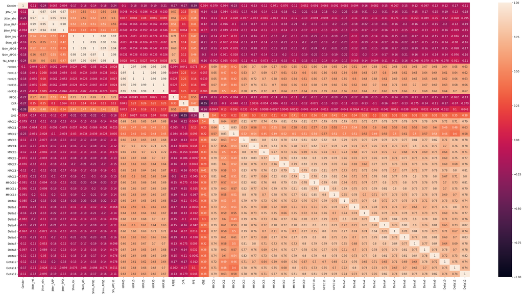

```python
fig_dims = (40, 20)
fig, ax = plt.subplots(figsize=fig_dims)
sns.heatmap(corr, annot = True, fmt='.2g', vmin=-1, vmax=1)
```

```python
threshold=0.9
```

```python
# find and remove correlated features
def correlation(dataset, threshold):
    col_corr = set()  # Set of all the names of correlated columns
    corr_matrix = dataset.corr()
    for i in range(len(corr_matrix.columns)):
        for j in range(i):
            if abs(corr_matrix.iloc[i, j]) > threshold: # we are interested in absolute coeff value
                colname = corr_matrix.columns[i]  # getting the name of column
                col_corr.add(colname)
    return col_corr
```

```python
cor_fe=correlation(X_train,threshold)
print(cor_fe)
len(cor_fe)
```

```
{'HNR15', 'Shim_APQ5', 'Shim_APQ3', 'HNR35', 'Jitter_abs', 'Shim_dB', 'HNR25', 'Shi_APQ11', 'Jitter_PPQ', 'HNR38', 'Jitter_RAP'}
```

```
11
```

```python
X_train_cor=X_train.drop(cor_fe,axis=1)
X_test_cor=X_test.drop(cor_fe,axis=1)
```

##### Dataset of features after using Correlation for feature selection

```python
X_train_cor.shape ,X_test_cor.shape
```

```
((180, 34), (60, 34))
```

#### Method 2 : Information Gain

```python
from sklearn.feature_selection import mutual_info_classif
```

```python
mutual_info=mutual_info_classif(X_train,y_train)
```

```python
mutual_data=pd.Series(mutual_info,index=X_train.columns)
mutual_data.sort_values(ascending=False)
```

```
HNR35         0.227463
HNR38         0.223150
Delta10       0.219153
HNR15         0.217382
Delta5        0.214989
Delta4        0.214314
MFCC10        0.208914
Delta9        0.208809
Delta11       0.200476
Delta12       0.200362
MFCC12        0.196625
Delta0        0.195455
Delta1        0.183270
Delta2        0.182239
MFCC5         0.179252
MFCC9         0.176758
MFCC0         0.176300
MFCC8         0.176171
MFCC4         0.174112
MFCC7         0.165558
Delta6        0.165391
HNR05         0.161253
MFCC6         0.159143
Delta3        0.157841
HNR25         0.155569
MFCC3         0.146374
Delta7        0.138859
GNE           0.138746
Delta8        0.125342
MFCC1         0.116299
MFCC11        0.109545
PPE           0.062922
Jitter_RAP    0.059849
DFA           0.053639
Shim_APQ5     0.046457
MFCC2         0.046414
Jitter_PPQ    0.045812
Jitter_rel    0.039961
Shi_APQ11     0.031073
Shim_dB       0.028976
Shim_APQ3     0.007526
Shim_loc      0.000378
RPDE          0.000000
Jitter_abs    0.000000
Gender        0.000000
dtype: float64
```

```python
IG_col=set(mutual_data.sort_values(ascending=False).index[0:15])
```

```python
X_train_IG=X_train[IG_col]
X_test_IG=X_test[IG_col]
```

##### Dataset of features after using Information Gain for feature selection

```python
X_train_IG.shape ,X_test_IG.shape
```

```
((180, 15), (60, 15))
```

#### Method 3 : Univariate Selection

```python
from sklearn.feature_selection import SelectKBest
from sklearn.feature_selection import chi2
```

```python
### Apply SelectKBest Algorithm
ordered_rank_features=SelectKBest(score_func=chi2)
ordered_feature=ordered_rank_features.fit(X_train,y_train)
```

```python
dfscores=pd.DataFrame(ordered_feature.scores_,columns=["Score"])
dfcolumns=pd.DataFrame(X_train.columns)
```

```python
features_rank=pd.concat([dfcolumns,dfscores],axis=1)
```

```python
features_rank.columns=['Features','Score']
features_rank
```

|  | Features | Score |
| --- | --- | --- |
| 0 | Gender | 0.269910 |
| 1 | Jitter_rel | 3.875527 |
| 2 | Jitter_abs | 0.000103 |
| 3 | Jitter_RAP | 0.029975 |
| 4 | Jitter_PPQ | 0.035534 |
| 5 | Shim_loc | 0.119406 |
| 6 | Shim_dB | 1.131048 |
| 7 | Shim_APQ3 | 0.084146 |
| 8 | Shim_APQ5 | 0.078258 |
| 9 | Shi_APQ11 | 0.053152 |
| 10 | HNR05 | 153.090828 |
| 11 | HNR15 | 170.589147 |
| 12 | HNR25 | 178.391894 |
| 13 | HNR35 | 196.838686 |
| 14 | HNR38 | 197.515857 |
| 15 | RPDE | 0.011095 |
| 16 | DFA | 0.000295 |
| 17 | PPE | 0.632252 |
| 18 | GNE | 0.017586 |
| 19 | MFCC0 | 1.538430 |
| 20 | MFCC1 | 1.049740 |
| 21 | MFCC2 | 0.624192 |
| 22 | MFCC3 | 1.848917 |
| 23 | MFCC4 | 1.694910 |
| 24 | MFCC5 | 1.849768 |
| 25 | MFCC6 | 1.582262 |
| 26 | MFCC7 | 1.474659 |
| 27 | MFCC8 | 1.558185 |
| 28 | MFCC9 | 1.524169 |
| 29 | MFCC10 | 1.894119 |
| 30 | MFCC11 | 1.635241 |
| 31 | MFCC12 | 1.717606 |
| 32 | Delta0 | 1.792190 |
| 33 | Delta1 | 1.957424 |
| 34 | Delta2 | 1.981398 |
| 35 | Delta3 | 1.531603 |
| 36 | Delta4 | 1.605611 |
| 37 | Delta5 | 1.673795 |
| 38 | Delta6 | 1.489873 |
| 39 | Delta7 | 1.742339 |
| 40 | Delta8 | 1.364843 |
| 41 | Delta9 | 1.638851 |
| 42 | Delta10 | 1.608634 |
| 43 | Delta11 | 2.323950 |
| 44 | Delta12 | 1.595003 |

```python
U_fe=(features_rank.nlargest(10,'Score'))
U_fe
```

|  | Features | Score |
| --- | --- | --- |
| 14 | HNR38 | 197.515857 |
| 13 | HNR35 | 196.838686 |
| 12 | HNR25 | 178.391894 |
| 11 | HNR15 | 170.589147 |
| 10 | HNR05 | 153.090828 |
| 1 | Jitter_rel | 3.875527 |
| 43 | Delta11 | 2.323950 |
| 34 | Delta2 | 1.981398 |
| 33 | Delta1 | 1.957424 |
| 29 | MFCC10 | 1.894119 |

```python
U_fe=set(U_fe['Features'])
```

##### Dataset of features after using Univariate Selection for feature selection

```python
X_train_U=X_train[U_fe]
X_test_U=X_test[U_fe]
```

```python
X_train_U.shape,X_test_U.shape
```

```
((180, 10), (60, 10))
```

#### Method 4 : Feature Importance

```python
from sklearn.ensemble import ExtraTreesClassifier
model=ExtraTreesClassifier()
model.fit(X_train,y_train)
```

```
ExtraTreesClassifier()
```

```python
print(model.feature_importances_)
```

```
[0.01670051 0.01048507 0.01104894 0.00783485 0.01013906 0.01125355
 0.01550355 0.01192438 0.01144357 0.01093893 0.02129428 0.02441645
 0.02761333 0.02740962 0.03268583 0.01673981 0.00960958 0.01877536
 0.01921995 0.02242753 0.02167421 0.01919945 0.03212515 0.01990197
 0.01731304 0.02525286 0.03276132 0.02346204 0.03224905 0.0308029
 0.03116317 0.01914036 0.02214094 0.031332   0.02390492 0.0318987
 0.03886314 0.03251025 0.02200581 0.01998205 0.01890518 0.02721212
 0.02570877 0.0352917  0.02773472]
```

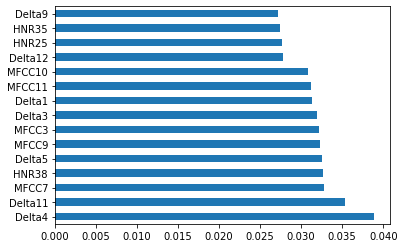

```python
ranked_features=pd.Series(model.feature_importances_,index=X.columns)
ranked_features.nlargest(15).plot(kind='barh')
plt.show()
```

```python
FI_fe=set(ranked_features.nlargest(15).index)
```

##### Dataset of features after using Feature Importance for feature selection

```python
X_train_FI=X_train[FI_fe]
X_test_FI=X_test[FI_fe]
```

```python
X_train_FI.shape,X_test_FI.shape
```

```
((180, 15), (60, 15))
```

## Step 3 : Build Predictive Model

```python
from sklearn.metrics import confusion_matrix
from sklearn import metrics, preprocessing

from sklearn.metrics import classification_report

from sklearn.model_selection import RandomizedSearchCV, GridSearchCV  # For Hyperameter Tuning
from sklearn.model_selection import cross_val_score
# from datetime import datetime


from sklearn.metrics import confusion_matrix
from sklearn import metrics, preprocessing
from sklearn.metrics import precision_score, recall_score ,f1_score , accuracy_score
from sklearn.metrics import plot_roc_curve, roc_curve, auc,plot_confusion_matrix
```

```python
# ## For Execution time

# def timer(start_time=None):
#     if not start_time:
#         start_time = datetime.now()
#         return start_time
#     elif start_time:
#         thour, temp_sec = divmod((datetime.now() - start_time).total_seconds(), 3600)
#         tmin, tsec = divmod(temp_sec, 60)
#         print('\n Time taken: %i hours %i minutes and %s seconds.' % (thour, tmin, round(tsec, 2)))
```

```python
Final_table={}
```

### Classifier 1: SVM

**1 - All features** , dataset: X_train , X_test  
**2 - Correlation** , dataset: X_train_cor , X_test_cor  
**3 - Information Gain** , dataset: X_train_IG , X_test_IG  
**4 - Univariate** , dataset: X_train_U , X_test_U  
**5 - Feature Importance** , dataset: X_train_FI , X_test_FI

```python
# Parameters for SVM classifier

params_svm = {'C': [0.1, 1, 10, 100, 1000],
              'gamma': [1, 0.1, 0.01, 0.001, 0.0001]}
```

```python
from sklearn.svm import SVC

# Creating SVM models

clf_svm1 = SVC(probability=True)

clf_svm2 = SVC(probability=True)

clf_svm3 = SVC(probability=True)

clf_svm4 = SVC(probability=True)

clf_svm5 = SVC(probability=True)
```

```python
# Hyperparameter tuning

random_search_svm1=RandomizedSearchCV(clf_svm1,param_distributions=params_svm,n_iter=5,
                                 scoring='roc_auc',n_jobs=-1,cv=5,verbose=3)
random_search_svm2=RandomizedSearchCV(clf_svm2,param_distributions=params_svm,n_iter=5,
                                 scoring='roc_auc',n_jobs=-1,cv=5,verbose=3)
random_search_svm3=RandomizedSearchCV(clf_svm3,param_distributions=params_svm,n_iter=5,
                                 scoring='roc_auc',n_jobs=-1,cv=5,verbose=3)
random_search_svm4=RandomizedSearchCV(clf_svm4,param_distributions=params_svm,n_iter=5,
                                 scoring='roc_auc',n_jobs=-1,cv=5,verbose=3)
random_search_svm5=RandomizedSearchCV(clf_svm5,param_distributions=params_svm,n_iter=5,
                                 scoring='roc_auc',n_jobs=-1,cv=5,verbose=3)
```

```python
# Searching for parameters

random_search_svm1.fit(X_train, y_train)
random_search_svm2.fit(X_train_cor, y_train)
random_search_svm3.fit(X_train_IG, y_train)
random_search_svm4.fit(X_train_U, y_train)
random_search_svm5.fit(X_train_FI, y_train)
```

```
Fitting 5 folds for each of 5 candidates, totalling 25 fits
Fitting 5 folds for each of 5 candidates, totalling 25 fits
Fitting 5 folds for each of 5 candidates, totalling 25 fits
Fitting 5 folds for each of 5 candidates, totalling 25 fits
Fitting 5 folds for each of 5 candidates, totalling 25 fits
```

```
RandomizedSearchCV(cv=5, estimator=SVC(probability=True), n_iter=5, n_jobs=-1,
                   param_distributions={'C': [0.1, 1, 10, 100, 1000],
                                        'gamma': [1, 0.1, 0.01, 0.001, 0.0001]},
                   scoring='roc_auc', verbose=3)
```

```python
# Assigining best parameters to models

clf_svm1 =random_search_svm1.best_estimator_

clf_svm2 =random_search_svm2.best_estimator_

clf_svm3 = random_search_svm3.best_estimator_

clf_svm4 = random_search_svm4.best_estimator_

clf_svm5 = random_search_svm5.best_estimator_


print(random_search_svm1.best_estimator_)
print(random_search_svm2.best_estimator_)
print(random_search_svm3.best_estimator_)
print(random_search_svm4.best_estimator_)
print(random_search_svm5.best_estimator_)
```

```
SVC(C=1000, gamma=0.0001, probability=True)
SVC(C=10, gamma=0.1, probability=True)
SVC(C=100, gamma=0.01, probability=True)
SVC(C=10, gamma=0.001, probability=True)
SVC(C=0.1, gamma=0.001, probability=True)
```

```python
# Testing Data

classifier_score_svm1 = clf_svm1.score(X_test, y_test)
classifier_score_svm2 = clf_svm2.score(X_test_cor, y_test)
classifier_score_svm3 = clf_svm3.score(X_test_IG, y_test)
classifier_score_svm4 = clf_svm4.score(X_test_U, y_test)
classifier_score_svm5 = clf_svm5.score(X_test_FI, y_test)
```

```python
# Accuracy of SVM models

classifier_score_svm1,classifier_score_svm2,classifier_score_svm3,classifier_score_svm4,classifier_score_svm5
```

```
(0.75, 0.8666666666666667, 0.7333333333333333, 0.8, 0.75)
```

```python
# Predicted Outputs

y_pred_svm1 = clf_svm1.fit(X_train, y_train).predict(X_test)
y_pred_svm2 = clf_svm2.fit(X_train_cor, y_train).predict(X_test_cor)
y_pred_svm3 = clf_svm3.fit(X_train_IG, y_train).predict(X_test_IG)
y_pred_svm4 = clf_svm4.fit(X_train_U, y_train).predict(X_test_U)
y_pred_svm5 = clf_svm5.fit(X_train_FI, y_train).predict(X_test_FI)
```

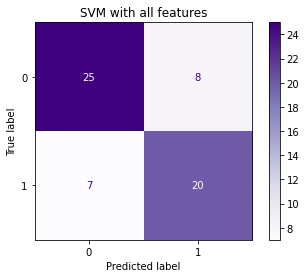

```python
# Confusion matrix for svm Model 1

plot_confusion_matrix(clf_svm1, X_test, y_test,cmap='Purples')
plt.title('SVM with all features')
plt.show()
```

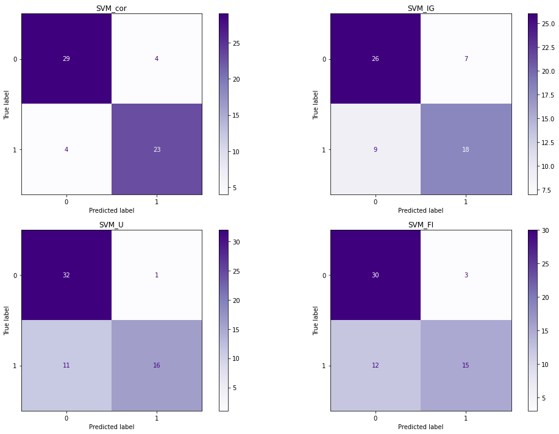

```python
# Confusion Matrix for svm Model 2 3 4 5

svm_classifiers=[clf_svm2,clf_svm3,clf_svm4,clf_svm5]
svm_test_data=[X_test_cor,X_test_IG,X_test_U,X_test_FI]
svm_titles=['SVM_cor','SVM_IG','SVM_U','SVM_FI']

fig, axes = plt.subplots(nrows=2, ncols=2, figsize=(15,10))
for cls, ax,Xtest,title in zip(svm_classifiers, axes.flatten(),svm_test_data,svm_titles):
    plot_confusion_matrix(cls, Xtest, y_test, ax=ax, cmap='Purples')
    ax.set_title(title)

plt.tight_layout()
plt.show()
```

```python
# Adding Data

Final_table['SVM']=[accuracy_score(y_test,y_pred_svm1),precision_score(y_test,y_pred_svm1),
                    recall_score(y_test,y_pred_svm1),f1_score(y_test,y_pred_svm1)]

Final_table['SVM_cor']=[accuracy_score(y_test,y_pred_svm2),precision_score(y_test,y_pred_svm2),
                    recall_score(y_test,y_pred_svm2),f1_score(y_test,y_pred_svm2)]

Final_table['SVM_IG']=[accuracy_score(y_test,y_pred_svm3),precision_score(y_test,y_pred_svm3),
                    recall_score(y_test,y_pred_svm3),f1_score(y_test,y_pred_svm3)]

Final_table['SVM_U']=[accuracy_score(y_test,y_pred_svm4),precision_score(y_test,y_pred_svm4),
                    recall_score(y_test,y_pred_svm4),f1_score(y_test,y_pred_svm4)]

Final_table['SVM_FI']=[accuracy_score(y_test,y_pred_svm5),precision_score(y_test,y_pred_svm5),
                    recall_score(y_test,y_pred_svm5),f1_score(y_test,y_pred_svm5)]
```

### Clasifier 2: Logistic Regression

**1 - All features** , dataset: X_train , X_test  
**2 - Correlation** , dataset: X_train_cor , X_test_cor  
**3 - Information Gain** , dataset: X_train_IG , X_test_IG  
**4 - Univariate** , dataset: X_train_U , X_test_U  
**5 - Feature Importance** , dataset: X_train_FI , X_test_FI

```python
# Parameters for LogisticRegression

params_LR= [
    {'penalty' : ['l1', 'l2', 'elasticnet', 'none'],
    'C' :  [0.1, 1, 10, 100, 1000],
    'solver' : ['lbfgs','newton-cg','liblinear','sag','saga'],
    'max_iter' : [100, 1000,2500, 5000]
    }
]
```

```python
import warnings
warnings.filterwarnings('ignore')
```

```python
# Creating LogisticRegression Models

from sklearn.linear_model import LogisticRegression

clf_LR1 = LogisticRegression()

clf_LR2 = LogisticRegression()

clf_LR3 = LogisticRegression()

clf_LR4 = LogisticRegression()

clf_LR5 = LogisticRegression()
```

```python
# Hyperparameter tuning

random_search_LR1=RandomizedSearchCV(clf_LR1,param_distributions=params_LR,n_iter=5,
                                 scoring='roc_auc',n_jobs=-1,cv=5,verbose=3)
random_search_LR2=RandomizedSearchCV(clf_LR2,param_distributions=params_LR,n_iter=5,
                                 scoring='roc_auc',n_jobs=-1,cv=5,verbose=3)
random_search_LR3=RandomizedSearchCV(clf_LR3,param_distributions=params_LR,n_iter=5,
                                 scoring='roc_auc',n_jobs=-1,cv=5,verbose=3)
random_search_LR4=RandomizedSearchCV(clf_LR4,param_distributions=params_LR,n_iter=5,
                                 scoring='roc_auc',n_jobs=-1,cv=5,verbose=3)
random_search_LR5=RandomizedSearchCV(clf_LR5,param_distributions=params_LR,n_iter=5,
                                 scoring='roc_auc',n_jobs=-1,cv=5,verbose=3)
```

```python
# Searching for Parameters

random_search_LR1.fit(X_train, y_train)
random_search_LR2.fit(X_train_cor, y_train)
random_search_LR3.fit(X_train_IG, y_train)
random_search_LR4.fit(X_train_U, y_train)
random_search_LR5.fit(X_train_FI, y_train)
```

```
Fitting 5 folds for each of 5 candidates, totalling 25 fits
Fitting 5 folds for each of 5 candidates, totalling 25 fits
Fitting 5 folds for each of 5 candidates, totalling 25 fits
Fitting 5 folds for each of 5 candidates, totalling 25 fits
Fitting 5 folds for each of 5 candidates, totalling 25 fits
```

```
RandomizedSearchCV(cv=5, estimator=LogisticRegression(), n_iter=5, n_jobs=-1,
                   param_distributions=[{'C': [0.1, 1, 10, 100, 1000],
                                         'max_iter': [100, 1000, 2500, 5000],
                                         'penalty': ['l1', 'l2', 'elasticnet',
                                                     'none'],
                                         'solver': ['lbfgs', 'newton-cg',
                                                    'liblinear', 'sag',
                                                    'saga']}],
                   scoring='roc_auc', verbose=3)
```

```python
# Assigining best parameters to models

clf_LR1 = random_search_LR1.best_estimator_

clf_LR2 = random_search_LR2.best_estimator_

clf_LR3 = random_search_LR3.best_estimator_

clf_LR4 = random_search_LR4.best_estimator_

clf_LR5 = random_search_LR5.best_estimator_
```

```python
# Test Data

classifier_score_LR1 = clf_LR1.score(X_test, y_test)
classifier_score_LR2 = clf_LR2.score(X_test_cor, y_test)
classifier_score_LR3 = clf_LR3.score(X_test_IG, y_test)
classifier_score_LR4 = clf_LR4.score(X_test_U, y_test)
classifier_score_LR5 = clf_LR5.score(X_test_FI, y_test)
```

```python
# Accuracy of LogisticRegression Models

classifier_score_LR1,classifier_score_LR2,classifier_score_LR3,classifier_score_LR4,classifier_score_LR5
```

```
(0.7666666666666667, 0.7666666666666667, 0.75, 0.75, 0.7666666666666667)
```

```python
# Predicted Outputs

y_pred_LR1 = clf_LR1.fit(X_train, y_train).predict(X_test)
y_pred_LR2 = clf_LR2.fit(X_train_cor, y_train).predict(X_test_cor)
y_pred_LR3 = clf_LR3.fit(X_train_IG, y_train).predict(X_test_IG)
y_pred_LR4 = clf_LR4.fit(X_train_U, y_train).predict(X_test_U)
y_pred_LR5 = clf_LR5.fit(X_train_FI, y_train).predict(X_test_FI)
```

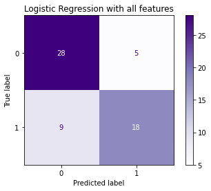

```python
# Confusion matrix for LR Model 1

plot_confusion_matrix(clf_LR1, X_test, y_test,cmap='Purples')
plt.title('Logistic Regression with all features')
plt.show()
```

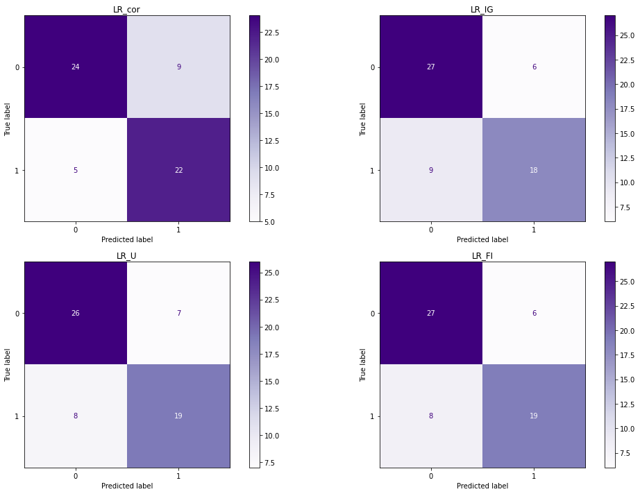

```python
# Confusion Matrix for LR Model 2 3 4 5

LR_classifiers=[clf_LR2,clf_LR3,clf_LR4,clf_LR5]
LR_test_data=[X_test_cor,X_test_IG,X_test_U,X_test_FI]
LR_titles=['LR_cor','LR_IG','LR_U','LR_FI']

fig, axes = plt.subplots(nrows=2, ncols=2, figsize=(15,10))
for cls, ax,Xtest,title in zip(LR_classifiers, axes.flatten(),LR_test_data,LR_titles):
    plot_confusion_matrix(cls, Xtest, y_test, ax=ax, cmap='Purples')
    ax.set_title(title)

plt.tight_layout()
plt.show()
```

```python
# Adding Data

Final_table['LR']=[accuracy_score(y_test,y_pred_LR1),precision_score(y_test,y_pred_LR1),
                    recall_score(y_test,y_pred_LR1),f1_score(y_test,y_pred_LR1)]

Final_table['LR_cor']=[accuracy_score(y_test,y_pred_LR2),precision_score(y_test,y_pred_LR2),
                    recall_score(y_test,y_pred_LR2),f1_score(y_test,y_pred_LR2)]

Final_table['LR_IG']=[accuracy_score(y_test,y_pred_LR3),precision_score(y_test,y_pred_LR3),
                    recall_score(y_test,y_pred_LR3),f1_score(y_test,y_pred_LR3)]

Final_table['LR_U']=[accuracy_score(y_test,y_pred_LR4),precision_score(y_test,y_pred_LR4),
                    recall_score(y_test,y_pred_LR4),f1_score(y_test,y_pred_LR4)]

Final_table['LR_FI']=[accuracy_score(y_test,y_pred_LR5),precision_score(y_test,y_pred_LR5),
                    recall_score(y_test,y_pred_LR5),f1_score(y_test,y_pred_LR5)]
```

### Clasifier 3: KNN

**1 - All features** , dataset: X_train , X_test  
**2 - Correlation** , dataset: X_train_cor , X_test_cor  
**3 - Information Gain** , dataset: X_train_IG , X_test_IG  
**4 - Univariate** , dataset: X_train_U , X_test_U  
**5 - Feature Importance** , dataset: X_train_FI , X_test_FI

```python
# Parameters for KNN

params_KNN=[
    {'n_neighbors' : [5,10,25,100],
     'weights' : ['uniform', 'distance'],
     'metric' : ['euclidean', 'manhattan', 'minkowski']
}
]
```

```python
# Creating KNN Models

from sklearn.neighbors import KNeighborsClassifier

clf_KNN1 = KNeighborsClassifier()


clf_KNN2 = KNeighborsClassifier()


clf_KNN3 = KNeighborsClassifier()


clf_KNN4 = KNeighborsClassifier()


clf_KNN5 = KNeighborsClassifier()
```

```python
# Hyperparameter tuning

random_search_KNN1=RandomizedSearchCV(clf_KNN1,param_distributions=params_KNN,n_iter=5,
                                 scoring='roc_auc',n_jobs=-1,cv=5,verbose=3)
random_search_KNN2=RandomizedSearchCV(clf_KNN2,param_distributions=params_KNN,n_iter=5,
                                 scoring='roc_auc',n_jobs=-1,cv=5,verbose=3)
random_search_KNN3=RandomizedSearchCV(clf_KNN3,param_distributions=params_KNN,n_iter=5,
                                 scoring='roc_auc',n_jobs=-1,cv=5,verbose=3)
random_search_KNN4=RandomizedSearchCV(clf_KNN4,param_distributions=params_KNN,n_iter=5,
                                 scoring='roc_auc',n_jobs=-1,cv=5,verbose=3)
random_search_KNN5=RandomizedSearchCV(clf_KNN5,param_distributions=params_KNN,n_iter=5,
                                 scoring='roc_auc',n_jobs=-1,cv=5,verbose=3)
```

```python
# Searching for Parameters

random_search_KNN1.fit(X_train, y_train)
random_search_KNN2.fit(X_train_cor, y_train)
random_search_KNN3.fit(X_train_IG, y_train)
random_search_KNN4.fit(X_train_U, y_train)
random_search_KNN5.fit(X_train_FI, y_train)
```

```
Fitting 5 folds for each of 5 candidates, totalling 25 fits
Fitting 5 folds for each of 5 candidates, totalling 25 fits
Fitting 5 folds for each of 5 candidates, totalling 25 fits
Fitting 5 folds for each of 5 candidates, totalling 25 fits
Fitting 5 folds for each of 5 candidates, totalling 25 fits
```

```
RandomizedSearchCV(cv=5, estimator=KNeighborsClassifier(), n_iter=5, n_jobs=-1,
                   param_distributions=[{'metric': ['euclidean', 'manhattan',
                                                    'minkowski'],
                                         'n_neighbors': [5, 10, 25, 100],
                                         'weights': ['uniform', 'distance']}],
                   scoring='roc_auc', verbose=3)
```

```python
# Assigining best parameters to models

clf_KNN1 = random_search_KNN1.best_estimator_

clf_KNN2 = random_search_KNN2.best_estimator_

clf_KNN3 = random_search_KNN3.best_estimator_

clf_KNN4 = random_search_KNN4.best_estimator_

clf_KNN5 = random_search_KNN5.best_estimator_
```

```python
# Test Data

classifier_score_KNN1 = clf_KNN1.score(X_test, y_test)
classifier_score_KNN2 = clf_KNN2.score(X_test_cor, y_test)
classifier_score_KNN3 = clf_KNN3.score(X_test_IG, y_test)
classifier_score_KNN4 = clf_KNN4.score(X_test_U, y_test)
classifier_score_KNN5 = clf_KNN5.score(X_test_FI, y_test)
```

```python
# Accuracy of KNN Models

classifier_score_KNN1,classifier_score_KNN2,classifier_score_KNN3,classifier_score_KNN4,classifier_score_KNN5
```

```
(0.8, 0.9, 0.7833333333333333, 0.7666666666666667, 0.7333333333333333)
```

```python
# Predicted Outputs

y_pred_KNN1 = clf_KNN1.fit(X_train, y_train).predict(X_test)
y_pred_KNN2 = clf_KNN2.fit(X_train_cor, y_train).predict(X_test_cor)
y_pred_KNN3 = clf_KNN3.fit(X_train_IG, y_train).predict(X_test_IG)
y_pred_KNN4 = clf_KNN4.fit(X_train_U, y_train).predict(X_test_U)
y_pred_KNN5 = clf_KNN5.fit(X_train_FI, y_train).predict(X_test_FI)
```

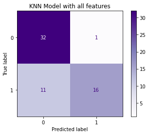

```python
# Confusion matrix for KNN Model 1

plot_confusion_matrix(clf_KNN1, X_test, y_test,cmap='Purples')
plt.title('KNN Model with all features')
plt.show()
```

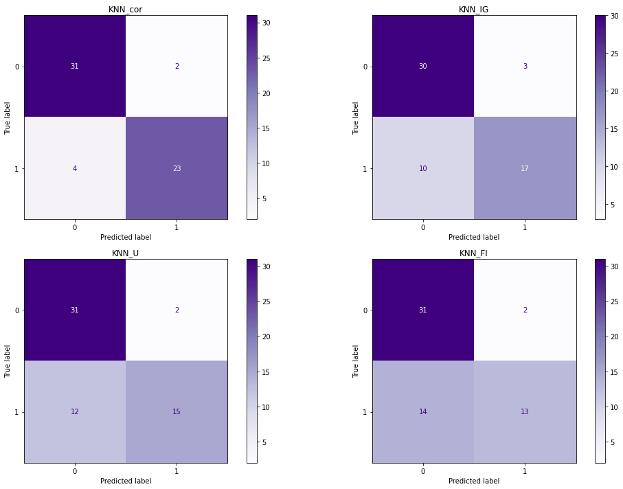

```python
# Confusion Matrix for KNN Model 2 3 4 5

KNN_classifiers=[clf_KNN2,clf_KNN3,clf_KNN4,clf_KNN5]
KNN_test_data=[X_test_cor,X_test_IG,X_test_U,X_test_FI]
KNN_titles=['KNN_cor','KNN_IG','KNN_U','KNN_FI']

fig, axes = plt.subplots(nrows=2, ncols=2, figsize=(15,10))
for cls, ax,Xtest,title in zip(KNN_classifiers, axes.flatten(),KNN_test_data,KNN_titles):
    plot_confusion_matrix(cls, Xtest, y_test, ax=ax, cmap='Purples')
    ax.set_title(title)

plt.tight_layout()
plt.show()
```

```python
# Adding Data

Final_table['KNN']=[accuracy_score(y_test,y_pred_KNN1),precision_score(y_test,y_pred_KNN1),
                    recall_score(y_test,y_pred_KNN1),f1_score(y_test,y_pred_KNN1)]

Final_table['KNN_cor']=[accuracy_score(y_test,y_pred_KNN2),precision_score(y_test,y_pred_KNN2),
                    recall_score(y_test,y_pred_KNN2),f1_score(y_test,y_pred_KNN2)]

Final_table['KNN_IG']=[accuracy_score(y_test,y_pred_KNN3),precision_score(y_test,y_pred_KNN3),
                    recall_score(y_test,y_pred_KNN3),f1_score(y_test,y_pred_KNN3)]

Final_table['KNN_U']=[accuracy_score(y_test,y_pred_KNN4),precision_score(y_test,y_pred_KNN4),
                    recall_score(y_test,y_pred_KNN4),f1_score(y_test,y_pred_KNN4)]

Final_table['KNN_FI']=[accuracy_score(y_test,y_pred_KNN5),precision_score(y_test,y_pred_KNN5),
                    recall_score(y_test,y_pred_KNN5),f1_score(y_test,y_pred_KNN5)]
```

### Clasifier 4: Random forest

**1 - All features** , dataset: X_train , X_test  
**2 - Correlation** , dataset: X_train_cor , X_test_cor  
**3 - Information Gain** , dataset: X_train_IG , X_test_IG  
**4 - Univariate** , dataset: X_train_U , X_test_U  
**5 - Feature Importance** , dataset: X_train_FI , X_test_FI

```python
# Parameters for RF

params_RF = [ {'max_depth': [6,9, None],
         'n_estimators':[50, 70, 100, 150],
          'criterion' : ['gini', 'entropy'],
          'bootstrap':[True, False],
          'min_samples_leaf': [1,2,3,4]}
        ]
```

```python
# Creating RF Models

from sklearn.ensemble import RandomForestClassifier

clf_RF1 = RandomForestClassifier()

clf_RF2 = RandomForestClassifier()

clf_RF3 = RandomForestClassifier()

clf_RF4 = RandomForestClassifier()

clf_RF5 = RandomForestClassifier()
```

```python
# Hyperparameter tuning

random_search_RF1=RandomizedSearchCV(clf_RF1,param_distributions=params_RF,n_iter=5,
                                 scoring='roc_auc',n_jobs=-1,cv=5,verbose=3)
random_search_RF2=RandomizedSearchCV(clf_RF2,param_distributions=params_RF,n_iter=5,
                                 scoring='roc_auc',n_jobs=-1,cv=5,verbose=3)
random_search_RF3=RandomizedSearchCV(clf_RF3,param_distributions=params_RF,n_iter=5,
                                 scoring='roc_auc',n_jobs=-1,cv=5,verbose=3)
random_search_RF4=RandomizedSearchCV(clf_RF4,param_distributions=params_RF,n_iter=5,
                                 scoring='roc_auc',n_jobs=-1,cv=5,verbose=3)
random_search_RF5=RandomizedSearchCV(clf_RF5,param_distributions=params_RF,n_iter=5,
                                 scoring='roc_auc',n_jobs=-1,cv=5,verbose=3)
```

```python
# Searching for Parameters

random_search_RF1.fit(X_train, y_train)
random_search_RF2.fit(X_train_cor, y_train)
random_search_RF3.fit(X_train_IG, y_train)
random_search_RF4.fit(X_train_U, y_train)
random_search_RF5.fit(X_train_FI, y_train)
```

```
Fitting 5 folds for each of 5 candidates, totalling 25 fits
Fitting 5 folds for each of 5 candidates, totalling 25 fits
Fitting 5 folds for each of 5 candidates, totalling 25 fits
Fitting 5 folds for each of 5 candidates, totalling 25 fits
Fitting 5 folds for each of 5 candidates, totalling 25 fits
```

```
RandomizedSearchCV(cv=5, estimator=RandomForestClassifier(), n_iter=5,
                   n_jobs=-1,
                   param_distributions=[{'bootstrap': [True, False],
                                         'criterion': ['gini', 'entropy'],
                                         'max_depth': [6, 9, None],
                                         'min_samples_leaf': [1, 2, 3, 4],
                                         'n_estimators': [50, 70, 100, 150]}],
                   scoring='roc_auc', verbose=3)
```

```python
# Assigining best parameters to models

clf_RF1 = random_search_RF1.best_estimator_

clf_RF2 = random_search_RF2.best_estimator_

clf_RF3 = random_search_RF3.best_estimator_

clf_RF4 = random_search_RF4.best_estimator_

clf_RF5 = random_search_RF5.best_estimator_
```

```python
# Test Data

classifier_score_RF1 = clf_RF1.score(X_test, y_test)
classifier_score_RF2 = clf_RF2.score(X_test_cor, y_test)
classifier_score_RF3 = clf_RF3.score(X_test_IG, y_test)
classifier_score_RF4 = clf_RF4.score(X_test_U, y_test)
classifier_score_RF5 = clf_RF5.score(X_test_FI, y_test)
```

```python
# Accuracy of KNN Models

classifier_score_RF1,classifier_score_RF2,classifier_score_RF3,classifier_score_RF4,classifier_score_RF5
```

```
(0.7833333333333333, 0.8, 0.75, 0.7833333333333333, 0.7833333333333333)
```

```python
# Predicted Outputs

y_pred_RF1 = clf_RF1.fit(X_train, y_train).predict(X_test)
y_pred_RF2 = clf_RF2.fit(X_train_cor, y_train).predict(X_test_cor)
y_pred_RF3 = clf_RF3.fit(X_train_IG, y_train).predict(X_test_IG)
y_pred_RF4 = clf_RF4.fit(X_train_U, y_train).predict(X_test_U)
y_pred_RF5 = clf_RF5.fit(X_train_FI, y_train).predict(X_test_FI)
```

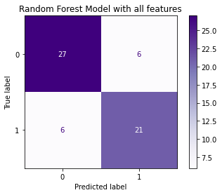

```python
# Confusion matrix for Random Forest Model 1

plot_confusion_matrix(clf_RF1, X_test, y_test,cmap='Purples')
plt.title('Random Forest Model with all features')
plt.show()
```

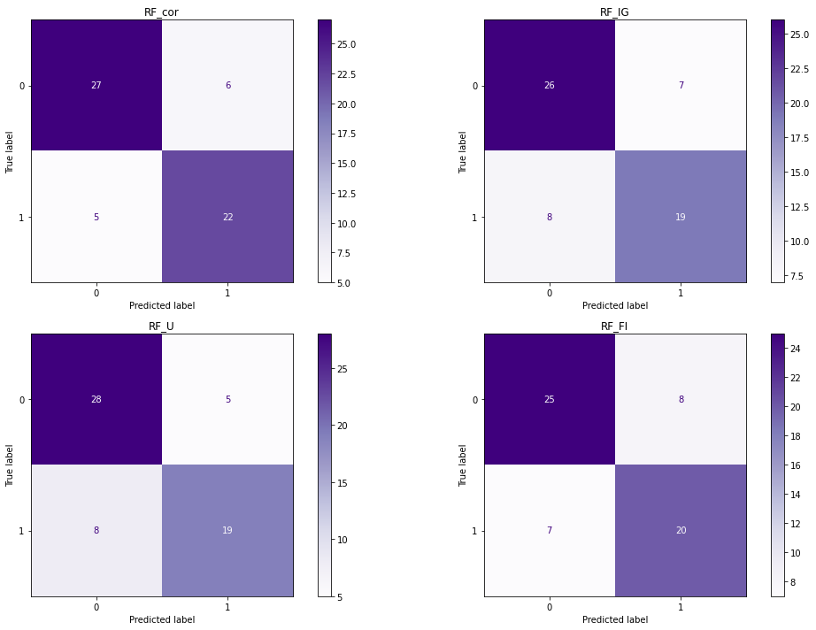

```python
# Confusion Matrix for Random Forest Model 2 3 4 5

RF_classifiers=[clf_RF2,clf_RF3,clf_RF4,clf_RF5]
RF_test_data=[X_test_cor,X_test_IG,X_test_U,X_test_FI]
RF_titles=['RF_cor','RF_IG','RF_U','RF_FI']

fig, axes = plt.subplots(nrows=2, ncols=2, figsize=(15,10))
for cls, ax,Xtest,title in zip(RF_classifiers, axes.flatten(),RF_test_data,RF_titles):
    plot_confusion_matrix(cls, Xtest, y_test, ax=ax, cmap='Purples')
    ax.set_title(title)

plt.tight_layout()
plt.show()
```

```python
# Adding Data

Final_table['RF']=[accuracy_score(y_test,y_pred_RF1),precision_score(y_test,y_pred_RF1),
                    recall_score(y_test,y_pred_RF1),f1_score(y_test,y_pred_RF1)]

Final_table['RF_cor']=[accuracy_score(y_test,y_pred_RF2),precision_score(y_test,y_pred_RF2),
                    recall_score(y_test,y_pred_RF2),f1_score(y_test,y_pred_RF2)]

Final_table['RF_IG']=[accuracy_score(y_test,y_pred_RF3),precision_score(y_test,y_pred_RF3),
                    recall_score(y_test,y_pred_RF3),f1_score(y_test,y_pred_RF3)]

Final_table['RF_U']=[accuracy_score(y_test,y_pred_RF4),precision_score(y_test,y_pred_RF4),
                    recall_score(y_test,y_pred_RF4),f1_score(y_test,y_pred_RF4)]

Final_table['RF_FI']=[accuracy_score(y_test,y_pred_RF5),precision_score(y_test,y_pred_RF5),
                    recall_score(y_test,y_pred_RF5),f1_score(y_test,y_pred_RF5)]
```

### Clasifier 5: Decision Tree Classifier

**1 - All features** , dataset: X_train , X_test  
**2 - Correlation** , dataset: X_train_cor , X_test_cor  
**3 - Information Gain** , dataset: X_train_IG , X_test_IG  
**4 - Univariate** , dataset: X_train_U , X_test_U  
**5 - Feature Importance** , dataset: X_train_FI , X_test_FI

```python
from scipy.stats import randint
```

```python
# Parameters for DT

params_DT = {"max_depth": [3, None],
              "max_features": randint(1, 9),
              "min_samples_leaf": randint(1, 9),
              "criterion": ["gini", "entropy"]}
```

```python
# Creating DT Models

from sklearn.tree import DecisionTreeClassifier

clf_DT1 = DecisionTreeClassifier()

clf_DT2 = DecisionTreeClassifier()

clf_DT3 = DecisionTreeClassifier()

clf_DT4 = DecisionTreeClassifier()

clf_DT5 = DecisionTreeClassifier()
```

```python
# Hyperparameter tuning

random_search_DT1=RandomizedSearchCV(clf_DT1,param_distributions=params_DT,n_iter=5,
                                 scoring='roc_auc',n_jobs=-1,cv=5,verbose=3)
random_search_DT2=RandomizedSearchCV(clf_DT2,param_distributions=params_DT,n_iter=5,
                                 scoring='roc_auc',n_jobs=-1,cv=5,verbose=3)
random_search_DT3=RandomizedSearchCV(clf_DT3,param_distributions=params_DT,n_iter=5,
                                 scoring='roc_auc',n_jobs=-1,cv=5,verbose=3)
random_search_DT4=RandomizedSearchCV(clf_DT4,param_distributions=params_DT,n_iter=5,
                                 scoring='roc_auc',n_jobs=-1,cv=5,verbose=3)
random_search_DT5=RandomizedSearchCV(clf_DT5,param_distributions=params_DT,n_iter=5,
                                 scoring='roc_auc',n_jobs=-1,cv=5,verbose=3)
```

```python
# Searching for Parameters

random_search_DT1.fit(X_train, y_train)
random_search_DT2.fit(X_train_cor, y_train)
random_search_DT3.fit(X_train_IG, y_train)
random_search_DT4.fit(X_train_U, y_train)
random_search_DT5.fit(X_train_FI, y_train)
```

```
Fitting 5 folds for each of 5 candidates, totalling 25 fits
Fitting 5 folds for each of 5 candidates, totalling 25 fits
Fitting 5 folds for each of 5 candidates, totalling 25 fits
Fitting 5 folds for each of 5 candidates, totalling 25 fits
Fitting 5 folds for each of 5 candidates, totalling 25 fits
```

```
RandomizedSearchCV(cv=5, estimator=DecisionTreeClassifier(), n_iter=5,
                   n_jobs=-1,
                   param_distributions={'criterion': ['gini', 'entropy'],
                                        'max_depth': [3, None],
                                        'max_features': <scipy.stats._distn_infrastructure.rv_frozen object at 0x7fd5369f2ee0>,
                                        'min_samples_leaf': <scipy.stats._distn_infrastructure.rv_frozen object at 0x7fd536a95160>},
                   scoring='roc_auc', verbose=3)
```

```python
# Assigining best parameters to models

clf_DT1 = random_search_DT1.best_estimator_

clf_DT2 = random_search_DT2.best_estimator_

clf_DT3 = random_search_DT3.best_estimator_

clf_DT4 = random_search_DT4.best_estimator_

clf_DT5 = random_search_DT5.best_estimator_
```

```python
# Test Data

classifier_score_DT1 = clf_DT1.score(X_test, y_test)
classifier_score_DT2 = clf_DT2.score(X_test_cor, y_test)
classifier_score_DT3 = clf_DT3.score(X_test_IG, y_test)
classifier_score_DT4 = clf_DT4.score(X_test_U, y_test)
classifier_score_DT5 = clf_DT5.score(X_test_FI, y_test)
```

```python
# Accuracy of DT Models

classifier_score_DT1,classifier_score_DT2,classifier_score_DT3,classifier_score_DT4,classifier_score_DT5
```

```
(0.7333333333333333,
 0.7166666666666667,
 0.7166666666666667,
 0.7833333333333333,
 0.7166666666666667)
```

```python
# Predicted Outputs

y_pred_DT1 = clf_DT1.fit(X_train, y_train).predict(X_test)
y_pred_DT2 = clf_DT2.fit(X_train_cor, y_train).predict(X_test_cor)
y_pred_DT3 = clf_DT3.fit(X_train_IG, y_train).predict(X_test_IG)
y_pred_DT4 = clf_DT4.fit(X_train_U, y_train).predict(X_test_U)
y_pred_DT5 = clf_DT5.fit(X_train_FI, y_train).predict(X_test_FI)
```

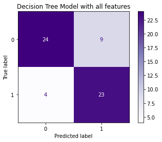

```python
# Confusion matrix for DT Model 1

plot_confusion_matrix(clf_DT1, X_test, y_test,cmap='Purples')
plt.title('Decision Tree Model with all features')
plt.show()
```

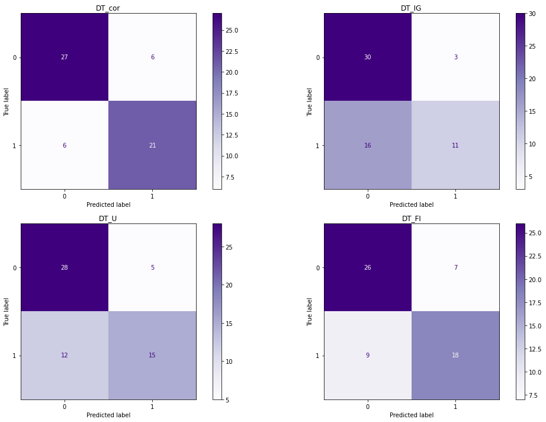

```python
# Confusion Matrix for KNN Model 2 3 4 5

DT_classifiers=[clf_DT2,clf_DT3,clf_DT4,clf_DT5]
DT_test_data=[X_test_cor,X_test_IG,X_test_U,X_test_FI]
DT_titles=['DT_cor','DT_IG','DT_U','DT_FI']

fig, axes = plt.subplots(nrows=2, ncols=2, figsize=(15,10))
for cls, ax,Xtest,title in zip(DT_classifiers, axes.flatten(),DT_test_data,DT_titles):
    plot_confusion_matrix(cls, Xtest, y_test, ax=ax, cmap='Purples')
    ax.set_title(title)

plt.tight_layout()
plt.show()
```

```python
# Adding Data

Final_table['DT']=[accuracy_score(y_test,y_pred_DT1),precision_score(y_test,y_pred_DT1),
                    recall_score(y_test,y_pred_DT1),f1_score(y_test,y_pred_DT1)]

Final_table['DT_cor']=[accuracy_score(y_test,y_pred_DT2),precision_score(y_test,y_pred_DT2),
                    recall_score(y_test,y_pred_DT2),f1_score(y_test,y_pred_DT2)]

Final_table['DT_IG']=[accuracy_score(y_test,y_pred_DT3),precision_score(y_test,y_pred_DT3),
                    recall_score(y_test,y_pred_DT3),f1_score(y_test,y_pred_DT3)]

Final_table['DT_U']=[accuracy_score(y_test,y_pred_DT4),precision_score(y_test,y_pred_DT4),
                    recall_score(y_test,y_pred_DT4),f1_score(y_test,y_pred_DT4)]

Final_table['DT_FI']=[accuracy_score(y_test,y_pred_DT5),precision_score(y_test,y_pred_DT5),
                    recall_score(y_test,y_pred_DT5),f1_score(y_test,y_pred_DT5)]
```

### Clasifier 6: Stochastic Gradient Descent

**1 - All features** , dataset: X_train , X_test  
**2 - Correlation** , dataset: X_train_cor , X_test_cor  
**3 - Information Gain** , dataset: X_train_IG , X_test_IG  
**4 - Univariate** , dataset: X_train_U , X_test_U  
**5 - Feature Importance** , dataset: X_train_FI , X_test_FI

```python
# Parameters for SGD

params_SGD = [
    {'loss': ['hinge', 'log', 'modified_huber', 'squared_hinge', 'perceptron'],
 'penalty': ['l1', 'l2', 'elasticnet'],
 'alpha': [0.0001, 0.001, 0.01, 0.1, 1, 10, 100, 1000],
 'learning_rate': ['constant', 'optimal', 'invscaling', 'adaptive'],
 'eta0': [1, 10, 100]
             }
]
# 'class_weight': [{1: 0.5, 0: 0.5},{1: 0.4, 0: 0.6},{1: 0.6, 0: 0.4},{1: 0.7, 0: 0.3}]
```

```python
# Creating DT Models

from sklearn.linear_model import SGDClassifier

clf_SGD1 = SGDClassifier()

clf_SGD2 = SGDClassifier()

clf_SGD3 =SGDClassifier()

clf_SGD4 = SGDClassifier()

clf_SGD5 = SGDClassifier()
```

```python
# Hyperparameter tuning

random_search_SGD1=RandomizedSearchCV(clf_SGD1,param_distributions=params_SGD,n_iter=5,
                                 scoring='roc_auc',n_jobs=-1,cv=5,verbose=3)
random_search_SGD2=RandomizedSearchCV(clf_SGD2,param_distributions=params_SGD,n_iter=5,
                                 scoring='roc_auc',n_jobs=-1,cv=5,verbose=3)
random_search_SGD3=RandomizedSearchCV(clf_SGD3,param_distributions=params_SGD,n_iter=5,
                                 scoring='roc_auc',n_jobs=-1,cv=5,verbose=3)
random_search_SGD4=RandomizedSearchCV(clf_SGD4,param_distributions=params_SGD,n_iter=5,
                                 scoring='roc_auc',n_jobs=-1,cv=5,verbose=3)
random_search_SGD5=RandomizedSearchCV(clf_SGD5,param_distributions=params_SGD,n_iter=5,
                                 scoring='roc_auc',n_jobs=-1,cv=5,verbose=3)
```

```python
# Searching for Parameters

random_search_SGD1.fit(X_train, y_train)
random_search_SGD2.fit(X_train_cor, y_train)
random_search_SGD3.fit(X_train_IG, y_train)
random_search_SGD4.fit(X_train_U, y_train)
random_search_SGD5.fit(X_train_FI, y_train)
```

```
Fitting 5 folds for each of 5 candidates, totalling 25 fits
Fitting 5 folds for each of 5 candidates, totalling 25 fits
Fitting 5 folds for each of 5 candidates, totalling 25 fits
Fitting 5 folds for each of 5 candidates, totalling 25 fits
Fitting 5 folds for each of 5 candidates, totalling 25 fits
```

```
RandomizedSearchCV(cv=5, estimator=SGDClassifier(), n_iter=5, n_jobs=-1,
                   param_distributions=[{'alpha': [0.0001, 0.001, 0.01, 0.1, 1,
                                                   10, 100, 1000],
                                         'eta0': [1, 10, 100],
                                         'learning_rate': ['constant',
                                                           'optimal',
                                                           'invscaling',
                                                           'adaptive'],
                                         'loss': ['hinge', 'log',
                                                  'modified_huber',
                                                  'squared_hinge',
                                                  'perceptron'],
                                         'penalty': ['l1', 'l2',
                                                     'elasticnet']}],
                   scoring='roc_auc', verbose=3)
```

```python
# Assigining best parameters to models

clf_SGD1 = random_search_SGD1.best_estimator_

clf_SGD2 = random_search_SGD2.best_estimator_

clf_SGD3 = random_search_SGD3.best_estimator_

clf_SGD4 = random_search_SGD4.best_estimator_

clf_SGD5 = random_search_SGD5.best_estimator_
```

```python
random_search_SGD4.best_estimator_
```

```
SGDClassifier(alpha=0.01, eta0=100, learning_rate='invscaling', loss='log',
              penalty='elasticnet')
```

```python
# Test Data

classifier_score_SGD1 = clf_SGD1.score(X_test, y_test)
classifier_score_SGD2 = clf_SGD2.score(X_test_cor, y_test)
classifier_score_SGD3 = clf_SGD3.score(X_test_IG, y_test)
classifier_score_SGD4 = clf_SGD4.score(X_test_U, y_test)
classifier_score_SGD5 = clf_SGD5.score(X_test_FI, y_test)
```

```python
# Accuracy of DT Models

classifier_score_SGD1,classifier_score_SGD2,classifier_score_SGD3,classifier_score_SGD4,classifier_score_SGD5
```

```
(0.7833333333333333, 0.65, 0.8, 0.7166666666666667, 0.7833333333333333)
```

```python
# Predicted Outputs

y_pred_SGD1 = clf_SGD1.fit(X_train, y_train).predict(X_test)
y_pred_SGD2 = clf_SGD2.fit(X_train_cor, y_train).predict(X_test_cor)
y_pred_SGD3 = clf_SGD3.fit(X_train_IG, y_train).predict(X_test_IG)
y_pred_SGD4 = clf_SGD4.fit(X_train_U, y_train).predict(X_test_U)
y_pred_SGD5 = clf_SGD5.fit(X_train_FI, y_train).predict(X_test_FI)
```

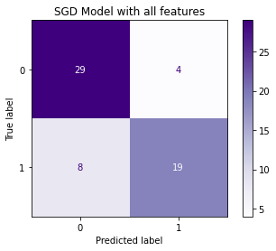

```python
# Confusion matrix for DT Model 1

plot_confusion_matrix(clf_SGD1, X_test, y_test,cmap='Purples')
plt.title('SGD Model with all features')
plt.show()
```

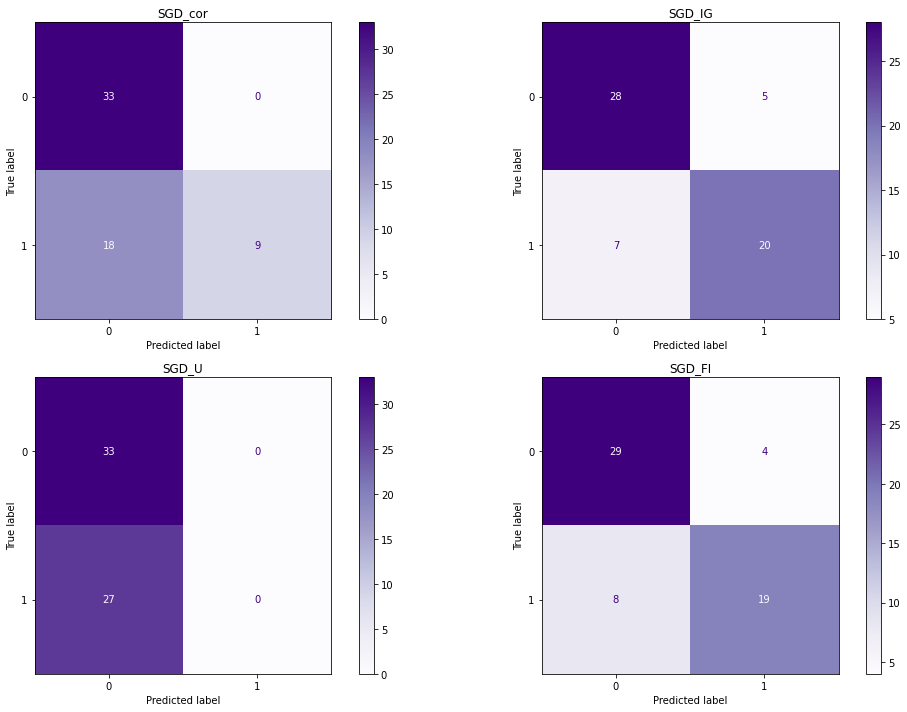

```python
# Confusion Matrix for KNN Model 2 3 4 5

SGD_classifiers=[clf_SGD2,clf_SGD3,clf_SGD4,clf_SGD5]
SGD_test_data=[X_test_cor,X_test_IG,X_test_U,X_test_FI]
SGD_titles=['SGD_cor','SGD_IG','SGD_U','SGD_FI']

fig, axes = plt.subplots(nrows=2, ncols=2, figsize=(15,10))
for cls, ax,Xtest,title in zip(SGD_classifiers, axes.flatten(),SGD_test_data,SGD_titles):
    plot_confusion_matrix(cls, Xtest, y_test, ax=ax, cmap='Purples')
    ax.set_title(title)

plt.tight_layout()
plt.show()
```

```python
# Adding Data

Final_table['SGD']=[accuracy_score(y_test,y_pred_SGD1),precision_score(y_test,y_pred_SGD1),
                    recall_score(y_test,y_pred_SGD1),f1_score(y_test,y_pred_SGD1)]

Final_table['SGD_cor']=[accuracy_score(y_test,y_pred_SGD2),precision_score(y_test,y_pred_SGD2),
                    recall_score(y_test,y_pred_SGD2),f1_score(y_test,y_pred_SGD2)]

Final_table['SGD_IG']=[accuracy_score(y_test,y_pred_SGD3),precision_score(y_test,y_pred_SGD3),
                    recall_score(y_test,y_pred_SGD3),f1_score(y_test,y_pred_SGD3)]

Final_table['SGD_U']=[accuracy_score(y_test,y_pred_SGD4),precision_score(y_test,y_pred_SGD4),
                    recall_score(y_test,y_pred_SGD4),f1_score(y_test,y_pred_SGD4)]

Final_table['SGD_FI']=[accuracy_score(y_test,y_pred_SGD5),precision_score(y_test,y_pred_SGD5),
                    recall_score(y_test,y_pred_SGD5),f1_score(y_test,y_pred_SGD5)]
```

### Clasifier 7: eXtreme Gradient Boosting

**1 - All features** , dataset: X_train , X_test  
**2 - Correlation** , dataset: X_train_cor , X_test_cor  
**3 - Information Gain** , dataset: X_train_IG , X_test_IG  
**4 - Univariate** , dataset: X_train_U , X_test_U  
**5 - Feature Importance** , dataset: X_train_FI , X_test_FI

```python
# Parameters for XGB


params_XGB=[ {
 "learning_rate"    : [0.05, 0.10, 0.15, 0.20, 0.25, 0.30 ] ,
 "max_depth"        : [ 3, 4, 5, 6, 8, 10, 12, 15],
 "min_child_weight" : [ 1, 3, 5, 7 ],
 "gamma"            : [ 0.0, 0.1, 0.2 , 0.3, 0.4 ],
 "colsample_bytree" : [ 0.3, 0.4, 0.5 , 0.7 ]

}
]
```

```python
# Creating XGB Models

from xgboost import XGBClassifier

clf_XGB1 = XGBClassifier()

clf_XGB2 = XGBClassifier()

clf_XGB3 = XGBClassifier()

clf_XGB4 = XGBClassifier()

clf_XGB5 = XGBClassifier()
```

```python
# Hyperparameter tuning

random_search_XGB1=RandomizedSearchCV(clf_XGB1,param_distributions=params_XGB,n_iter=5,
                                 scoring='roc_auc',n_jobs=-1,cv=5,verbose=3)
random_search_XGB2=RandomizedSearchCV(clf_XGB2,param_distributions=params_XGB,n_iter=5,
                                 scoring='roc_auc',n_jobs=-1,cv=5,verbose=3)
random_search_XGB3=RandomizedSearchCV(clf_XGB3,param_distributions=params_XGB,n_iter=5,
                                 scoring='roc_auc',n_jobs=-1,cv=5,verbose=3)
random_search_XGB4=RandomizedSearchCV(clf_XGB4,param_distributions=params_XGB,n_iter=5,
                                 scoring='roc_auc',n_jobs=-1,cv=5,verbose=3)
random_search_XGB5=RandomizedSearchCV(clf_XGB5,param_distributions=params_XGB,n_iter=5,
                                 scoring='roc_auc',n_jobs=-1,cv=5,verbose=3)
```

```python
# Searching for Parameters

random_search_XGB1.fit(X_train, y_train)
random_search_XGB2.fit(X_train_cor, y_train)
random_search_XGB3.fit(X_train_IG, y_train)
random_search_XGB4.fit(X_train_U, y_train)
random_search_XGB5.fit(X_train_FI, y_train)
```

[output not shown]

```
RandomizedSearchCV(cv=5,
                   estimator=XGBClassifier(base_score=None, booster=None,
                                           colsample_bylevel=None,
                                           colsample_bynode=None,
                                           colsample_bytree=None, gamma=None,
                                           gpu_id=None, importance_type='gain',
                                           interaction_constraints=None,
                                           learning_rate=None,
                                           max_delta_step=None, max_depth=None,
                                           min_child_weight=None, missing=nan,
                                           monotone_constraints=None,
                                           n_estimators=100,...
                                           reg_lambda=None,
                                           scale_pos_weight=None,
                                           subsample=None, tree_method=None,
                                           validate_parameters=None,
                                           verbosity=None),
                   n_iter=5, n_jobs=-1,
                   param_distributions=[{'colsample_bytree': [0.3, 0.4, 0.5,
                                                              0.7],
                                         'gamma': [0.0, 0.1, 0.2, 0.3, 0.4],
                                         'learning_rate': [0.05, 0.1, 0.15, 0.2,
                                                           0.25, 0.3],
                                         'max_depth': [3, 4, 5, 6, 8, 10, 12,
                                                       15],
                                         'min_child_weight': [1, 3, 5, 7]}],
                   scoring='roc_auc', verbose=3)
```

```python
# Assigining best parameters to models

clf_XGB1 = random_search_XGB1.best_estimator_

clf_XGB2 = random_search_XGB2.best_estimator_

clf_XGB3 = random_search_XGB3.best_estimator_

clf_XGB4 = random_search_XGB4.best_estimator_

clf_XGB5 = random_search_XGB5.best_estimator_
```

```python
# Test Data

classifier_score_XGB1 = clf_XGB1.score(X_test, y_test)
classifier_score_XGB2 = clf_XGB2.score(X_test_cor, y_test)
classifier_score_XGB3 = clf_XGB3.score(X_test_IG, y_test)
classifier_score_XGB4 = clf_XGB4.score(X_test_U, y_test)
classifier_score_XGB5 = clf_XGB5.score(X_test_FI, y_test)
```

```python
# Accuracy of XGB Models

classifier_score_XGB1,classifier_score_XGB2,classifier_score_XGB3,classifier_score_XGB4,classifier_score_XGB5
```

```
(0.8, 0.8166666666666667, 0.7666666666666667, 0.8, 0.7666666666666667)
```

```python
# Predicted Outputs

y_pred_XGB1 = clf_XGB1.fit(X_train, y_train).predict(X_test)
y_pred_XGB2 = clf_XGB2.fit(X_train_cor, y_train).predict(X_test_cor)
y_pred_XGB3 = clf_XGB3.fit(X_train_IG, y_train).predict(X_test_IG)
y_pred_XGB4 = clf_XGB4.fit(X_train_U, y_train).predict(X_test_U)
y_pred_XGB5 = clf_XGB5.fit(X_train_FI, y_train).predict(X_test_FI)
```

[output not shown]

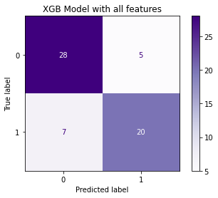

```python
# Confusion matrix for XGB Model 1

plot_confusion_matrix(clf_XGB1, X_test, y_test,cmap='Purples')
plt.title('XGB Model with all features')
plt.show()
```

[figure not shown]

```python
# Confusion Matrix for XGB Model 2 3 4 5

XGB_classifiers=[clf_XGB2,clf_XGB3,clf_XGB4,clf_XGB5]
XGB_test_data=[X_test_cor,X_test_IG,X_test_U,X_test_FI]
XGB_titles=['XGB_cor','XGB_IG','XGB_U','XGB_FI']

fig, axes = plt.subplots(nrows=2, ncols=2, figsize=(15,10))
for cls, ax,Xtest,title in zip(SGD_classifiers, axes.flatten(),XGB_test_data,XGB_titles):
    plot_confusion_matrix(cls, Xtest, y_test, ax=ax, cmap='Purples')
    ax.set_title(title)

plt.tight_layout()
plt.show()
```

```python
# Adding Data

Final_table['XGB']=[accuracy_score(y_test,y_pred_XGB1),precision_score(y_test,y_pred_XGB1),
                    recall_score(y_test,y_pred_XGB1),f1_score(y_test,y_pred_XGB1)]

Final_table['XGB_cor']=[accuracy_score(y_test,y_pred_XGB2),precision_score(y_test,y_pred_XGB2),
                    recall_score(y_test,y_pred_XGB2),f1_score(y_test,y_pred_XGB2)]

Final_table['XGB_IG']=[accuracy_score(y_test,y_pred_XGB3),precision_score(y_test,y_pred_XGB3),
                    recall_score(y_test,y_pred_XGB3),f1_score(y_test,y_pred_XGB3)]

Final_table['XGB_U']=[accuracy_score(y_test,y_pred_XGB4),precision_score(y_test,y_pred_XGB4),
                    recall_score(y_test,y_pred_XGB4),f1_score(y_test,y_pred_XGB4)]

Final_table['XGB_FI']=[accuracy_score(y_test,y_pred_XGB5),precision_score(y_test,y_pred_XGB5),
                    recall_score(y_test,y_pred_XGB5),f1_score(y_test,y_pred_XGB5)]
```

```python
scores_df = pd.DataFrame(data = Final_table)
scores_df_T = scores_df.transpose()
scores_df_T.columns = ['accuracy', 'precision', 'recall', 'F1']
scores_df_T
```

|  | accuracy | precision | recall | F1 |
| --- | --- | --- | --- | --- |
| SVM | 0.750000 | 0.714286 | 0.740741 | 0.727273 |
| SVM_cor | 0.866667 | 0.851852 | 0.851852 | 0.851852 |
| SVM_IG | 0.733333 | 0.720000 | 0.666667 | 0.692308 |
| SVM_U | 0.800000 | 0.941176 | 0.592593 | 0.727273 |
| SVM_FI | 0.750000 | 0.833333 | 0.555556 | 0.666667 |
| LR | 0.766667 | 0.782609 | 0.666667 | 0.720000 |
| LR_cor | 0.766667 | 0.709677 | 0.814815 | 0.758621 |
| LR_IG | 0.750000 | 0.750000 | 0.666667 | 0.705882 |
| LR_U | 0.750000 | 0.730769 | 0.703704 | 0.716981 |
| LR_FI | 0.766667 | 0.760000 | 0.703704 | 0.730769 |
| KNN | 0.800000 | 0.941176 | 0.592593 | 0.727273 |
| KNN_cor | 0.900000 | 0.920000 | 0.851852 | 0.884615 |
| KNN_IG | 0.783333 | 0.850000 | 0.629630 | 0.723404 |
| KNN_U | 0.766667 | 0.882353 | 0.555556 | 0.681818 |
| KNN_FI | 0.733333 | 0.866667 | 0.481481 | 0.619048 |
| RF | 0.800000 | 0.777778 | 0.777778 | 0.777778 |
| RF_cor | 0.816667 | 0.785714 | 0.814815 | 0.800000 |
| RF_IG | 0.750000 | 0.730769 | 0.703704 | 0.716981 |
| RF_U | 0.783333 | 0.791667 | 0.703704 | 0.745098 |
| RF_FI | 0.750000 | 0.714286 | 0.740741 | 0.727273 |
| DT | 0.783333 | 0.718750 | 0.851852 | 0.779661 |
| DT_cor | 0.800000 | 0.777778 | 0.777778 | 0.777778 |
| DT_IG | 0.683333 | 0.785714 | 0.407407 | 0.536585 |
| DT_U | 0.716667 | 0.750000 | 0.555556 | 0.638298 |
| DT_FI | 0.733333 | 0.720000 | 0.666667 | 0.692308 |
| SGD | 0.800000 | 0.826087 | 0.703704 | 0.760000 |
| SGD_cor | 0.700000 | 1.000000 | 0.333333 | 0.500000 |
| SGD_IG | 0.800000 | 0.800000 | 0.740741 | 0.769231 |
| SGD_U | 0.550000 | 0.000000 | 0.000000 | 0.000000 |
| SGD_FI | 0.800000 | 0.826087 | 0.703704 | 0.760000 |
| XGB | 0.800000 | 0.800000 | 0.740741 | 0.769231 |
| XGB_cor | 0.816667 | 0.785714 | 0.814815 | 0.800000 |
| XGB_IG | 0.766667 | 0.740741 | 0.740741 | 0.740741 |
| XGB_U | 0.800000 | 0.777778 | 0.777778 | 0.777778 |
| XGB_FI | 0.766667 | 0.740741 | 0.740741 | 0.740741 |